# Chapter 9 Statistical Foundations

## Samples and Populations

The population considered in the book is contained in the *nycflights13* dataset. In the *nycflights13* dataset contains all of the departing flights from airports in the NYC Area.

```r
library(pacman)

p_load(mdsr, nycflights13, tidyverse, skimr)
```

Recall the *flights* dataframe.

```r
flights
```

```
# A tibble: 336,776 × 19
    year month   day dep_time sched_dep_time dep_delay arr_time sched_arr_time
   <int> <int> <int>    <int>          <int>     <dbl>    <int>          <int>
 1  2013     1     1      517            515         2      830            819
 2  2013     1     1      533            529         4      850            830
 3  2013     1     1      542            540         2      923            850
 4  2013     1     1      544            545        -1     1004           1022
 5  2013     1     1      554            600        -6      812            837
 6  2013     1     1      554            558        -4      740            728
 7  2013     1     1      555            600        -5      913            854
 8  2013     1     1      557            600        -3      709            723
 9  2013     1     1      557            600        -3      838            846
10  2013     1     1      558            600        -2      753            745
# ℹ 336,766 more rows
# ℹ 11 more variables: arr_delay <dbl>, carrier <chr>, flight <int>,
#   tailnum <chr>, origin <chr>, dest <chr>, air_time <dbl>, distance <dbl>,
#   hour <dbl>, minute <dbl>, time_hour <dttm>
```

Take a sample of flights from NYC to SF. Get all of the flights to SF and take a sample of 25 of them.

Note that I did not set a seed for the sample, so your answers will differ from what is in the book.

```r
SF <- flights %>%
  filter(dest == "SFO", !is.na(arr_delay))
SF
```

```
# A tibble: 13,173 × 19
    year month   day dep_time sched_dep_time dep_delay arr_time sched_arr_time
   <int> <int> <int>    <int>          <int>     <dbl>    <int>          <int>
 1  2013     1     1      558            600        -2      923            937
 2  2013     1     1      611            600        11      945            931
 3  2013     1     1      655            700        -5     1037           1045
 4  2013     1     1      729            730        -1     1049           1115
 5  2013     1     1      734            737        -3     1047           1113
 6  2013     1     1      745            745         0     1135           1125
 7  2013     1     1      746            746         0     1119           1129
 8  2013     1     1      803            800         3     1132           1144
 9  2013     1     1      826            817         9     1145           1158
10  2013     1     1     1029           1030        -1     1427           1355
# ℹ 13,163 more rows
# ℹ 11 more variables: arr_delay <dbl>, carrier <chr>, flight <int>,
#   tailnum <chr>, origin <chr>, dest <chr>, air_time <dbl>, distance <dbl>,
#   hour <dbl>, minute <dbl>, time_hour <dttm>
```

```r
sf_25 <- SF %>%
  slice_sample(n = 25)
sf_25
```

```
# A tibble: 25 × 19
    year month   day dep_time sched_dep_time dep_delay arr_time sched_arr_time
   <int> <int> <int>    <int>          <int>     <dbl>    <int>          <int>
 1  2013     8    12     1021           1030        -9     1351           1345
 2  2013    10    28     1544           1529        15     1912           1847
 3  2013     7    19      836            840        -4     1127           1143
 4  2013     6    12     1023           1029        -6     1338           1348
 5  2013    10    16      834            834         0     1159           1156
 6  2013     9    27     1528           1530        -2     1856           1853
 7  2013     1    20      652            700        -8     1021           1045
 8  2013    11     7     2125           2120         5       54            100
 9  2013     3    12     1956           1949         7     2250           2321
10  2013     7     7     2204           1525       399      107           1823
# ℹ 15 more rows
# ℹ 11 more variables: arr_delay <dbl>, carrier <chr>, flight <int>,
#   tailnum <chr>, origin <chr>, dest <chr>, air_time <dbl>, distance <dbl>,
#   hour <dbl>, minute <dbl>, time_hour <dttm>
```

Get the summary statistics for the sample taken.

```r
sf_25 %>%
  skim(arr_delay)
```

Data summary

| Name | Piped data |
| --- | --- |
| Number of rows | 25 |
| Number of columns | 19 |
| _______________________ |  |
| Column type frequency: |  |
| numeric | 1 |
| ________________________ |  |
| Group variables | None |

**Variable type: numeric**

| skim_variable | n_missing | complete_rate | mean | sd | p0 | p25 | p50 | p75 | p100 | hist |
| --- | --- | --- | --- | --- | --- | --- | --- | --- | --- | --- |
| arr_delay | 0 | 1 | 12.04 | 86.44 | -51 | -23 | -6 | 9 | 404 | ▇▁▁▁▁ |

Since the SF dataset contains all flights from NYC to SF in 2013, the statistics computed from the SF dataset are the calculated population paramaters.

```r
SF %>%
  skim(arr_delay)
```

Data summary

| Name | Piped data |
| --- | --- |
| Number of rows | 13173 |
| Number of columns | 19 |
| _______________________ |  |
| Column type frequency: |  |
| numeric | 1 |
| ________________________ |  |
| Group variables | None |

**Variable type: numeric**

| skim_variable | n_missing | complete_rate | mean | sd | p0 | p25 | p50 | p75 | p100 | hist |
| --- | --- | --- | --- | --- | --- | --- | --- | --- | --- | --- |
| arr_delay | 0 | 1 | 2.67 | 47.67 | -86 | -23 | -8 | 12 | 1007 | ▇▁▁▁▁ |

Get the 98th percentile of the sample.

```r
sf_25 %>%
  summarize(q98 = quantile(arr_delay, p = 0.98))
```

```
# A tibble: 1 × 1
    q98
  <dbl>
1  245.
```

Get the estimated proportion of flights to SF with a delay less than 90 minutes.

```r
SF %>%
  group_by(arr_delay < 90) %>%
  count() %>%
  mutate(pct = n / nrow(SF))
```

```
# A tibble: 2 × 3
# Groups:   arr_delay < 90 [2]
  `arr_delay < 90`     n    pct
  <lgl>            <int>  <dbl>
1 FALSE              640 0.0486
2 TRUE             12533 0.951
```

Compare with the 98th percentile. 90 minutes is the 95th percentile.

```r
SF %>%
  summarize(q98 = quantile(arr_delay, p = 0.98))
```

```
# A tibble: 1 × 1
    q98
  <dbl>
1   153
```

## Sample Statistics

The sampling distribution.

Usually sampling is done without replacement.

```r
n <- 25
SF %>%
  slice_sample(n = n) %>%
  summarize(mean_arr_delay = mean(arr_delay))
```

```
# A tibble: 1 × 1
  mean_arr_delay
           <dbl>
1          -4.72
```

Note that different random sample produce different values for the sample statistic.

```r
SF %>%
  slice_sample(n = n) %>%
  summarize(mean_arr_delay = mean(arr_delay))
```

```
# A tibble: 1 × 1
  mean_arr_delay
           <dbl>
1           5.76
```

Using simulation we can approximate the sampling distribution of the sample statistics. Here we are computing the mean, but we could do this for any statistic we are interested in, the median, sample variance, sample standard deviation, etc.

```r
num_trials <- 500
sf_25_means <- 1:num_trials %>%
  map_dfr(
    ~ SF %>%
      slice_sample(n = n) %>%
      summarize(mean_arr_delay = mean(arr_delay))
  ) %>%
  mutate(n = n)

head(sf_25_means)
```

```
# A tibble: 6 × 2
  mean_arr_delay     n
           <dbl> <dbl>
1          -7.4     25
2           2.44    25
3          10.2     25
4         -10.8     25
5          -5.52    25
6          -3.96    25
```

Summarize the sample means.

```r
sf_25_means %>%
  skim(mean_arr_delay)
```

Data summary

| Name | Piped data |
| --- | --- |
| Number of rows | 500 |
| Number of columns | 2 |
| _______________________ |  |
| Column type frequency: |  |
| numeric | 1 |
| ________________________ |  |
| Group variables | None |

**Variable type: numeric**

| skim_variable | n_missing | complete_rate | mean | sd | p0 | p25 | p50 | p75 | p100 | hist |
| --- | --- | --- | --- | --- | --- | --- | --- | --- | --- | --- |
| mean_arr_delay | 0 | 1 | 1.48 | 9.07 | -15.6 | -4.78 | 0.52 | 6.24 | 45.84 | ▅▇▂▁▁ |

Confidence intervals

```r
sf_25_means %>%
  summarize(
    x_bar = mean(mean_arr_delay),
    se = sd(mean_arr_delay)
  ) %>%
  mutate(
    ci_lower = x_bar - 2 * se, # approximately 95% of observations
    ci_upper = x_bar + 2 * se  # are within two standard errors
  )
```

```
# A tibble: 1 × 4
  x_bar    se ci_lower ci_upper
  <dbl> <dbl>    <dbl>    <dbl>
1  1.48  9.07    -16.7     19.6
```

Using a larger sample size give a smaller Standard Error.

```r
n <- 100
sf_100_means <- 1:500 %>%
  map_dfr(
    ~ SF %>%
      slice_sample(n = n) %>%
      summarize(mean_arr_delay = mean(arr_delay))
  ) %>%
  mutate(n = n)
```

Plots to compare the sampling distributions with different sample sizes.

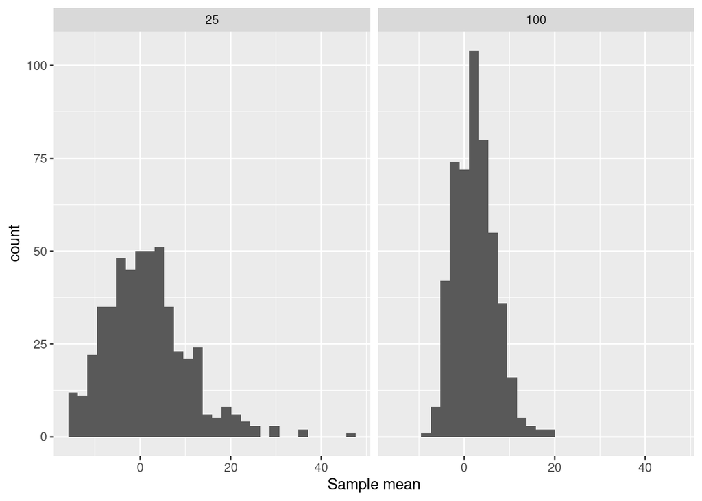

```r
sf_25_means %>%
  bind_rows(sf_100_means) %>%
  ggplot(aes(x = mean_arr_delay)) +
  geom_histogram(bins = 30) +
  facet_grid( ~ n) +
  xlab("Sample mean")
```

## Boostrap

Usually for random sampling we sample without replacement.

```r
three_flights <- SF %>%
  slice_sample(n = 3, replace = FALSE) %>%
  select(year, month, day, dep_time)
three_flights
```

```
# A tibble: 3 × 4
   year month   day dep_time
  <int> <int> <int>    <int>
1  2013    12    24     2020
2  2013     6     9     1554
3  2013     6    29     1040
```

With the Bootstrap we use sampling **with replacement**

```r
three_flights %>% slice_sample(n = 3, replace = TRUE)
```

```
# A tibble: 3 × 4
   year month   day dep_time
  <int> <int> <int>    <int>
1  2013     6    29     1040
2  2013    12    24     2020
3  2013     6    29     1040
```

```r
n <- 200
orig_sample <- SF %>%
  slice_sample(n = n, replace = FALSE)
orig_sample
```

```
# A tibble: 200 × 19
    year month   day dep_time sched_dep_time dep_delay arr_time sched_arr_time
   <int> <int> <int>    <int>          <int>     <dbl>    <int>          <int>
 1  2013     1    14     1127           1031        56     1438           1403
 2  2013     2     2      601            600         1      930            927
 3  2013     9     5     1903           1850        13     2211           2220
 4  2013     6    10     2017           1939        38     2359           2318
 5  2013     7     2     1758           1729        29     2050           2055
 6  2013     1    25     1425           1429        -4     1801           1754
 7  2013    11    15     1832           1834        -2     2155           2209
 8  2013     2     2      745            745         0     1136           1125
 9  2013    12     7      904            909        -5     1259           1248
10  2013     9    16     1650           1700       -10     2004           2027
# ℹ 190 more rows
# ℹ 11 more variables: arr_delay <dbl>, carrier <chr>, flight <int>,
#   tailnum <chr>, origin <chr>, dest <chr>, air_time <dbl>, distance <dbl>,
#   hour <dbl>, minute <dbl>, time_hour <dttm>
```

The reason for sampling with replacement is that we only have the Original Sample of size $n$. We do not have the population. So if we sampled with out replacement we would only have one sample to look at. Sampling the Original Sample with replace allow us to general lots of samples and to investiage the variability of these samples.

```r
orig_sample %>%
  slice_sample(n = n, replace = TRUE) %>%
  summarize(mean_arr_delay = mean(arr_delay))
```

```
# A tibble: 1 × 1
  mean_arr_delay
           <dbl>
1           1.40
```

```r
sf_200_bs <- 1:num_trials %>%
  map_dfr(
    ~orig_sample %>%
      slice_sample(n = n, replace = TRUE) %>%
      summarize(mean_arr_delay = mean(arr_delay))
  ) %>%
  mutate(n = n)

sf_200_bs %>%
  skim(mean_arr_delay)
```

Data summary

| Name | Piped data |
| --- | --- |
| Number of rows | 500 |
| Number of columns | 2 |
| _______________________ |  |
| Column type frequency: |  |
| numeric | 1 |
| ________________________ |  |
| Group variables | None |

**Variable type: numeric**

| skim_variable | n_missing | complete_rate | mean | sd | p0 | p25 | p50 | p75 | p100 | hist |
| --- | --- | --- | --- | --- | --- | --- | --- | --- | --- | --- |
| mean_arr_delay | 0 | 1 | 3.24 | 2.79 | -5.28 | 1.34 | 3.08 | 5 | 11.19 | ▁▅▇▅▁ |

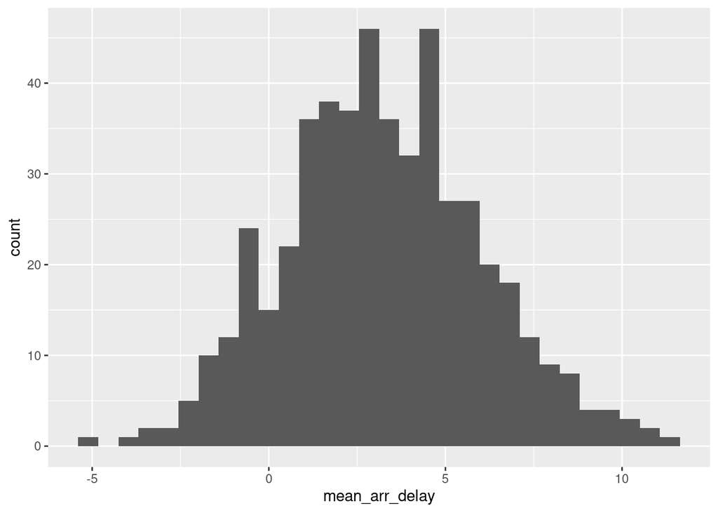

```r
sf_200_bs %>% ggplot(aes(x = mean_arr_delay)) +
  geom_histogram()
```

```r
sf_200_pop <- 1:num_trials %>%
  map_dfr(
    ~SF %>%
      slice_sample(n = n, replace = TRUE) %>%
      summarize(mean_arr_delay = mean(arr_delay))
  ) %>%
  mutate(n = n)

sf_200_pop %>%
  skim(mean_arr_delay)
```

Data summary

| Name | Piped data |
| --- | --- |
| Number of rows | 500 |
| Number of columns | 2 |
| _______________________ |  |
| Column type frequency: |  |
| numeric | 1 |
| ________________________ |  |
| Group variables | None |

**Variable type: numeric**

| skim_variable | n_missing | complete_rate | mean | sd | p0 | p25 | p50 | p75 | p100 | hist |
| --- | --- | --- | --- | --- | --- | --- | --- | --- | --- | --- |
| mean_arr_delay | 0 | 1 | 2.52 | 3.41 | -7 | 0.17 | 2.33 | 4.54 | 16.57 | ▁▇▇▁▁ |

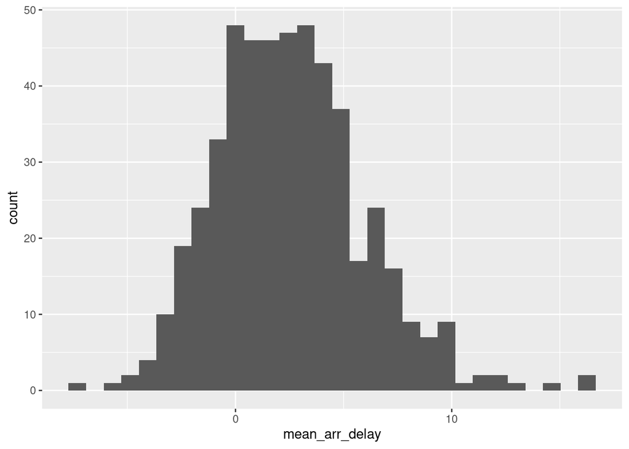

```r
sf_200_pop %>% ggplot(aes(x = mean_arr_delay)) +
  geom_histogram()
```

**Question:** Do the histograms look somewhat similar?

```r
orig_sample %>%
  summarize(q98 = quantile(arr_delay, p = 0.98))
```

```
# A tibble: 1 × 1
    q98
  <dbl>
1  130.
```

```r
n <- nrow(orig_sample)
sf_200_bs <- 1:num_trials %>%
  map_dfr(
    ~orig_sample %>%
      slice_sample(n = n, replace = TRUE) %>%
      summarize(q98 = quantile(arr_delay, p = 0.98))
  )

sf_200_bs %>%
  skim(q98)
```

Data summary

| Name | Piped data |
| --- | --- |
| Number of rows | 500 |
| Number of columns | 1 |
| _______________________ |  |
| Column type frequency: |  |
| numeric | 1 |
| ________________________ |  |
| Group variables | None |

**Variable type: numeric**

| skim_variable | n_missing | complete_rate | mean | sd | p0 | p25 | p50 | p75 | p100 | hist |
| --- | --- | --- | --- | --- | --- | --- | --- | --- | --- | --- |
| q98 | 0 | 1 | 129.82 | 28.22 | 62.34 | 111.18 | 121.32 | 137.6 | 234 | ▁▇▂▂▁ |

```r
n_large <- 10000
sf_10000_bs <- SF %>%
  slice_sample(n = n_large, replace = FALSE)

sf_200_bs <- 1:num_trials %>%
  map_dfr(~sf_10000_bs %>%
        slice_sample(n = n_large, replace = TRUE) %>%
        summarize(q98 = quantile(arr_delay, p = 0.98))
  )

sf_200_bs %>%
  skim(q98)
```

Data summary

| Name | Piped data |
| --- | --- |
| Number of rows | 500 |
| Number of columns | 1 |
| _______________________ |  |
| Column type frequency: |  |
| numeric | 1 |
| ________________________ |  |
| Group variables | None |

**Variable type: numeric**

| skim_variable | n_missing | complete_rate | mean | sd | p0 | p25 | p50 | p75 | p100 | hist |
| --- | --- | --- | --- | --- | --- | --- | --- | --- | --- | --- |
| q98 | 0 | 1 | 152.22 | 4.86 | 137.04 | 150 | 152 | 155 | 169 | ▁▂▇▂▁ |

## outliers

```r
SF %>%
  filter(arr_delay >= 420) %>%
  select(month, day, dep_delay, arr_delay, carrier)
```

```
# A tibble: 7 × 5
  month   day dep_delay arr_delay carrier
  <int> <int>     <dbl>     <dbl> <chr>
1    12     7       374       422 UA
2     7     6       589       561 DL
3     7     7       629       676 VX
4     7     7       653       632 VX
5     7    10       453       445 B6
6     7    10       432       433 VX
7     9    20      1014      1007 AA
```

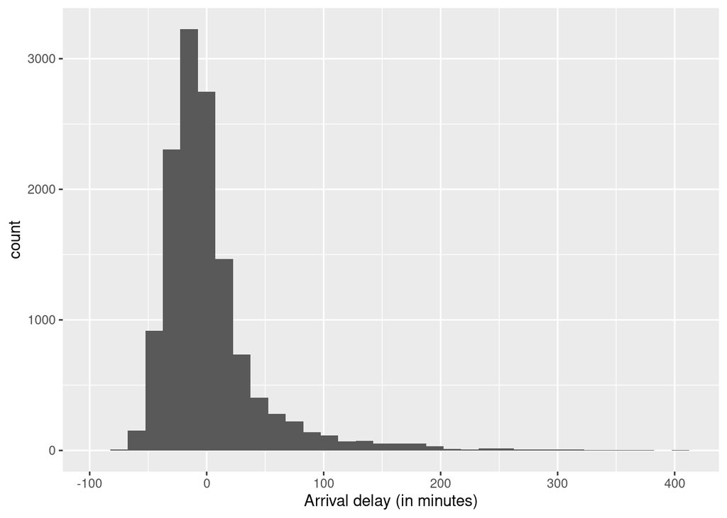

```r
SF %>%
  filter(arr_delay < 420) %>%
  ggplot(aes(arr_delay)) +
  geom_histogram(binwidth = 15) +
  labs(x = "Arrival delay (in minutes)")
```

```r
SF %>%
  group_by(hour) %>%
  count() %>%
  pivot_wider(names_from = hour, values_from = n) %>%
  data.frame()
```

```
  X5  X6   X7  X8  X9  X10 X11 X12 X13 X14 X15 X16  X17  X18 X19 X20 X21
1 55 663 1696 987 429 1744 413 504 476 528 946 897 1491 1091 731 465  57
```

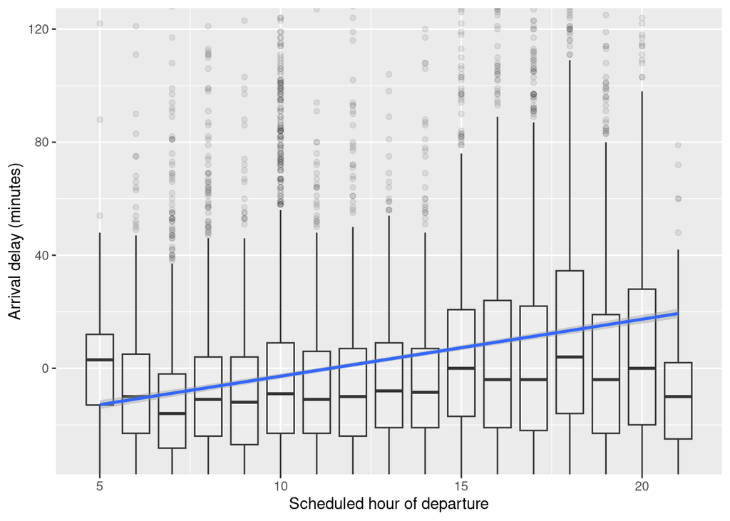

```r
SF %>%
  ggplot(aes(x = hour, y = arr_delay)) +
  geom_boxplot(alpha = 0.1, aes(group = hour)) +
  geom_smooth(method = "lm") +
  xlab("Scheduled hour of departure") +
  ylab("Arrival delay (minutes)") +
  coord_cartesian(ylim = c(-30, 120))
```

```r
mod1 <- lm(arr_delay ~ hour, data = SF)
broom::tidy(mod1)
```

```
# A tibble: 2 × 5
  term        estimate std.error statistic   p.value
  <chr>          <dbl>     <dbl>     <dbl>     <dbl>
1 (Intercept)   -22.9     1.23       -18.6 2.88e- 76
2 hour            2.01    0.0915      22.0 1.78e-105
```